# Bayesian Linear Regression - Howell Data

Keith McNulty

```r
knitr::opts_chunk$set(message = FALSE, warning = FALSE)
library(tidyverse)
```

## Obtaining and viewing data

We obtain the data census data for !Kung San and filter to adults:

```r
library(rethinking)
data(Howell1)
d <- Howell1

d2 <- d %>%
  dplyr::filter(age >= 18)
```

We plot the density of the height of the adults:

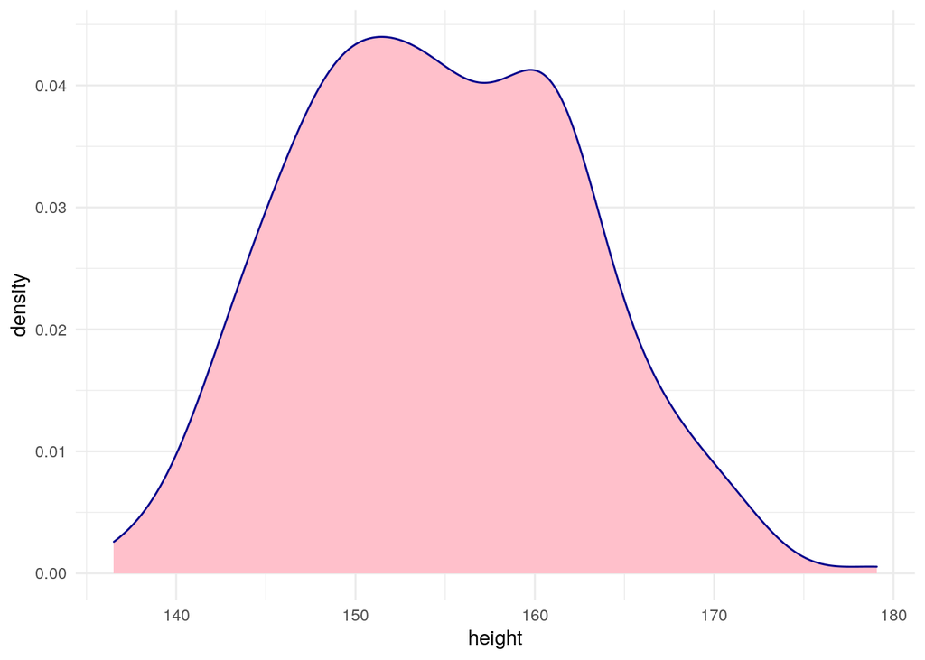

```r
ggplot(data = d2) +
  geom_density(aes(x = height), color = "darkblue", fill = "pink") +
  theme_minimal()
```

## Proposing a prior

Let’s look at what our prior would look like under these assumptions, based on 10,000 sample observations:

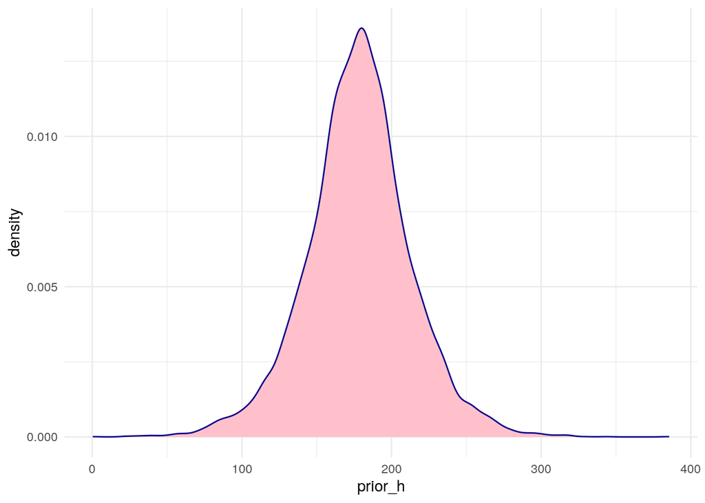

```r
sample_mu <- rnorm(1e4, mean = 178, sd = 20)
sample_sigma <- runif(1e4, 0, 50)
prior_h <- rnorm(1e4, mean = sample_mu, sd = sample_sigma)

ggplot() +
  geom_density(aes(x = prior_h), color = "darkblue", fill = "pink") +
  theme_minimal()
```

## Grid approximating the posterior

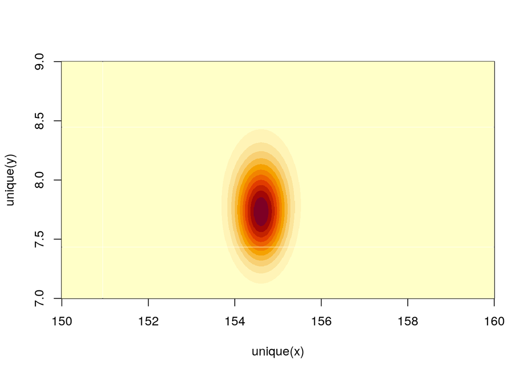

```r
mu.list <- seq(from = 150, to = 160, length.out = 1000)
sigma.list <- seq(from = 7, to = 9, length.out = 1000)
post <- expand.grid(mu = mu.list, sigma = sigma.list)

post$LL <- sapply(1:nrow(post), function(i) {
  sum(dnorm(d2$height, mean = post$mu[i], sd = post$sigma[i], log = TRUE))
})

post$prod = post$LL + dnorm(post$mu, mean = 178, sd = 20, log = TRUE) +
  dunif(post$sigma, min = 0, max = 50, log = TRUE)
post$prob <- exp(post$prod - max(post$prod))


rethinking::image_xyz(post$mu, post$sigma, post$prob)
```

## Sampling from the posterior

We take 10,000 samples from the grid-approximated posterior and plot the results:

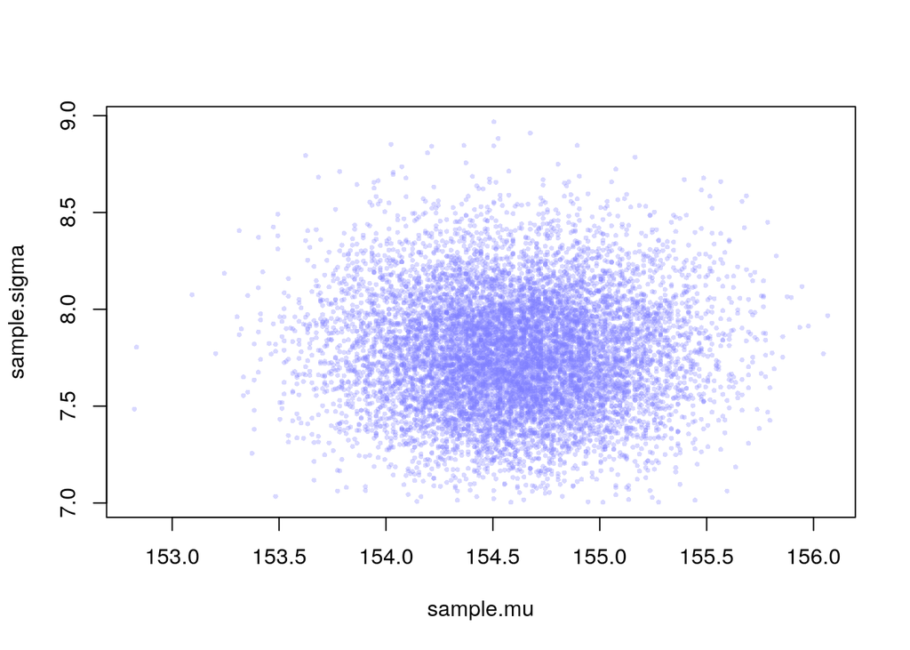

```r
sample.rows <- sample(1:nrow(post), size = 10000, replace = TRUE, prob = post$prob)
sample.mu <- post$mu[sample.rows]
sample.sigma <- post$sigma[sample.rows]

plot(sample.mu, sample.sigma, cex = 0.5, pch = 16, col = col.alpha(rangi2, 0.3))
```

Let’s look at the density plot for $\mu$:

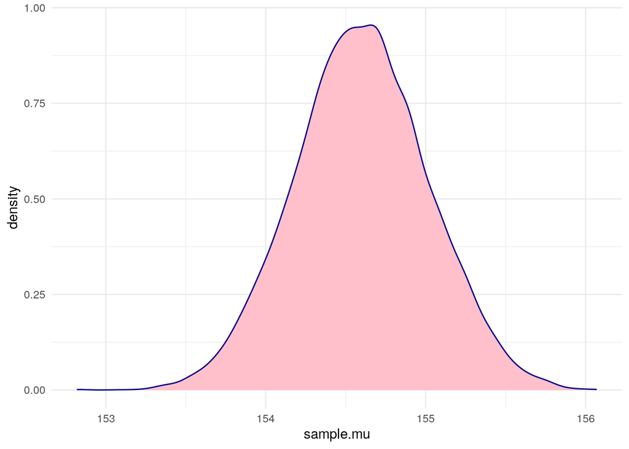

```r
ggplot() +
  geom_density(aes(x = sample.mu), color = "darkblue", fill = "pink") +
  theme_minimal()
```

And the same for $\sigma$:

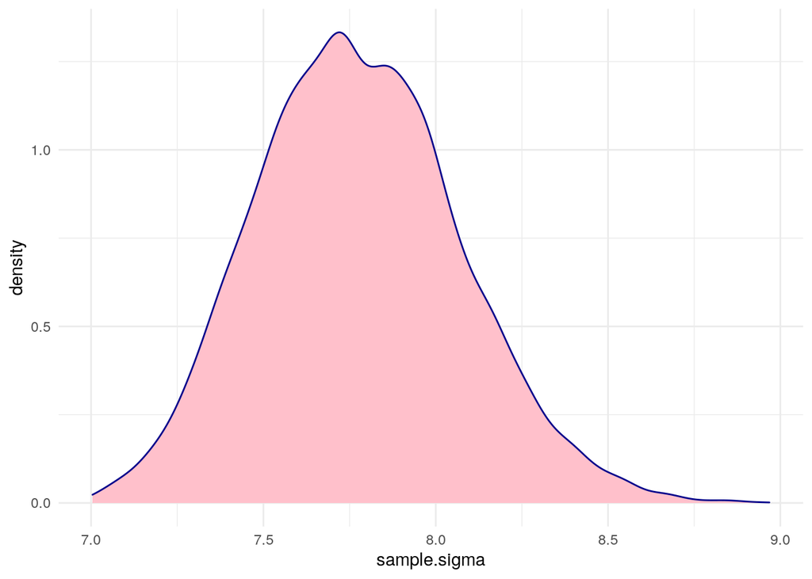

```r
ggplot() +
  geom_density(aes(x = sample.sigma), color = "darkblue", fill = "pink") +
  theme_minimal()
```

Let’s get posterior intervals:

```r
PI(sample.mu)
```

```
##       5%      94%
## 153.9239 155.2753
```

```r
PI(sample.sigma)
```

```
##       5%      94%
## 7.324324 8.261261
```

## Quadratic approximation

Now we estimate the posterior through quadratic approximation. First we define the model:

```r
flist <- alist(
  height ~ dnorm(mu, sigma),
  mu ~ dnorm(178, 20),
  sigma ~ dunif(0, 50)
)
```

Now we fit it with the $d2$ data and take a look at the posterior distribution:

```r
m4.1 <- quap(flist, data = d2)
precis(m4.1)
```

```
##             mean        sd       5.5%      94.5%
## mu    154.607025 0.4119948 153.948578 155.265472
## sigma   7.731336 0.2913863   7.265644   8.197028
```

Try with a much more precise prior for $\mu$:

```r
m4.2 <- quap(
  alist(
    height ~ dnorm(mu, sigma),
    mu ~ dnorm(178, 0.1),
    sigma ~ dunif(0, 50)
  ),
  data = d2
)

precis(m4.2)
```

```
##            mean        sd      5.5%     94.5%
## mu    177.86375 0.1002354 177.70356 178.02395
## sigma  24.51756 0.9289234  23.03296  26.00216
```

See matrix of covariances for `m4.1`:

```r
vcov(m4.1)
```

```
##                 mu        sigma
## mu    0.1697397388 0.0002180674
## sigma 0.0002180674 0.0849059819
```

To sample the posterior, we take samples of $\mu$ and $\sigma$ for the mutidimensional Gaussian distribution:

```r
post <- rethinking::extract.samples(m4.1, n = 1e4)
precis(post)
```

```
##             mean        sd       5.5%      94.5%     histogram
## mu    154.599231 0.4055847 153.950352 155.250437       ▁▁▅▇▂▁▁
## sigma   7.732129 0.2898885   7.262405   8.187088 ▁▁▁▁▂▅▇▇▃▁▁▁▁
```

## Linear relationships

Let’s plot height against weight in the adult Howell data:

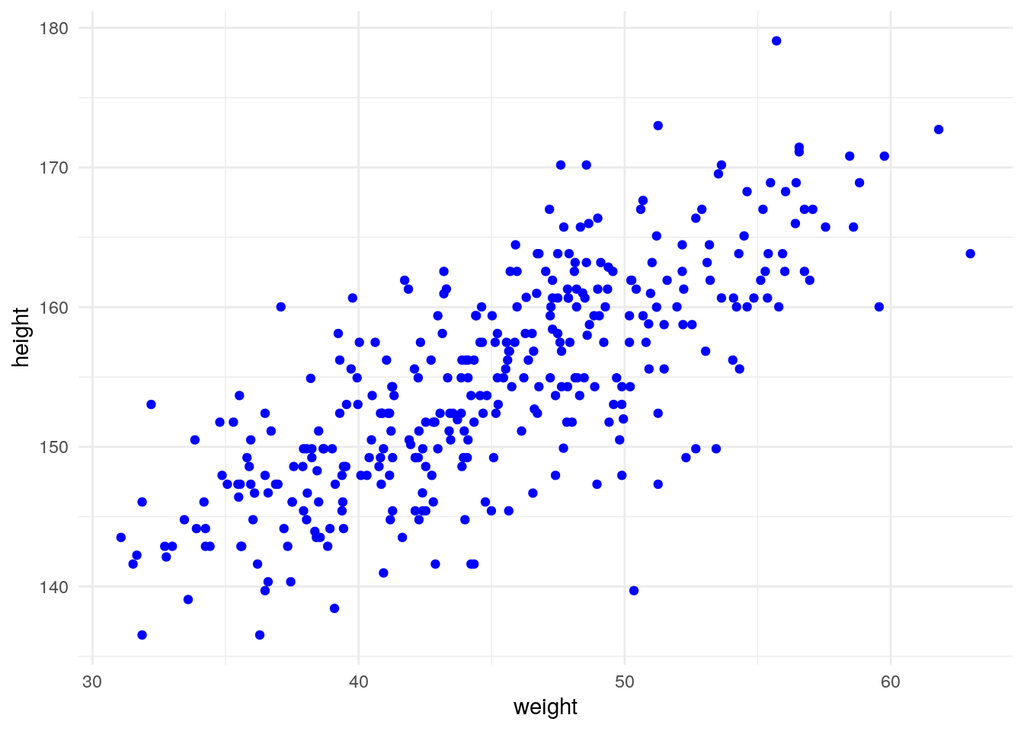

```r
ggplot(data = d2) +
  geom_point(aes(x = weight, y = height), color = "blue") +
  theme_minimal()
```

So we anticipate that our heights relate in some way to our weights. We can redefine our model to estimate the mean of each prior to be linearly dependent on the weight variable.

```r
# mean of x
meanweight <- mean(d2$weight)

new_mod <- alist(
  height ~ dnorm(mu, sigma),
  mu <- a + b*(weight - meanweight),
  a ~ dnorm(178, 20),
  b ~ dnorm(0, 1),
  sigma ~ dunif(0, 50)
)

m4.3 <- quap(new_mod, data = d2)
precis(m4.3)
```

```
##              mean         sd        5.5%       94.5%
## a     154.6013672 0.27030768 154.1693634 155.0333711
## b       0.9034414 0.04189139   0.8364908   0.9703919
## sigma   5.0718813 0.19115478   4.7663791   5.3773836
```

View the variance-covariance matrix for `m4.3`:

```r
round(vcov(m4.3), 3)
```

```
##           a     b sigma
## a     0.073 0.000 0.000
## b     0.000 0.002 0.000
## sigma 0.000 0.000 0.037
```

Plot the mean posterior against the data:

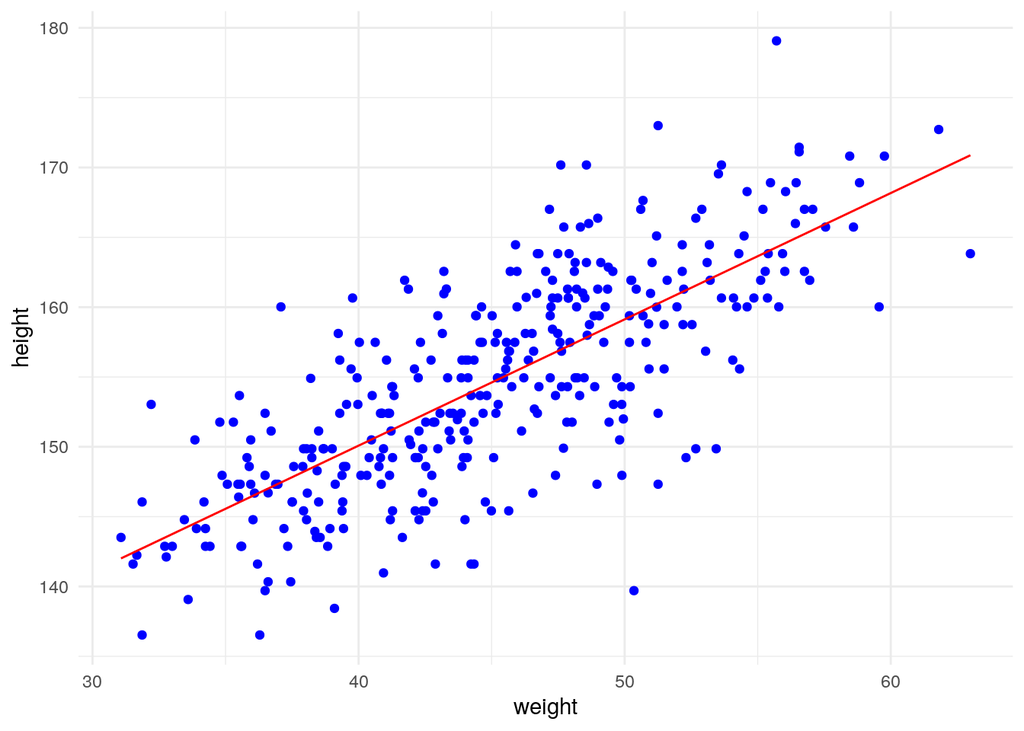

```r
post <- extract.samples(m4.3, n = 1e4)
mean_a <- mean(post$a)
mean_b <- mean(post$b)

ggplot(data = d2, aes(x = weight, y = height)) +
  geom_point(color = "blue") +
  geom_function(fun = function(x) {mean_a + mean_b *(x - meanweight)}, color = "red") +
  theme_minimal()
```

Now we want to plot uncertainty around our mean posterior. This command produces 1000 estimates of mu (rows) for each observation of the data in `d2` (columns).

```r
mu <- link(m4.3)
dim(mu)
```

```
## [1] 1000  352
```

We can get the same set of estimates for a specific et of weight values:

```r
weight.seq <- seq(from = 25, to = 70, by = 1)
mu <- link(m4.3, data = data.frame(weight = weight.seq))
dim(mu)
```

```
## [1] 1000   46
```

Let’s plot these values:

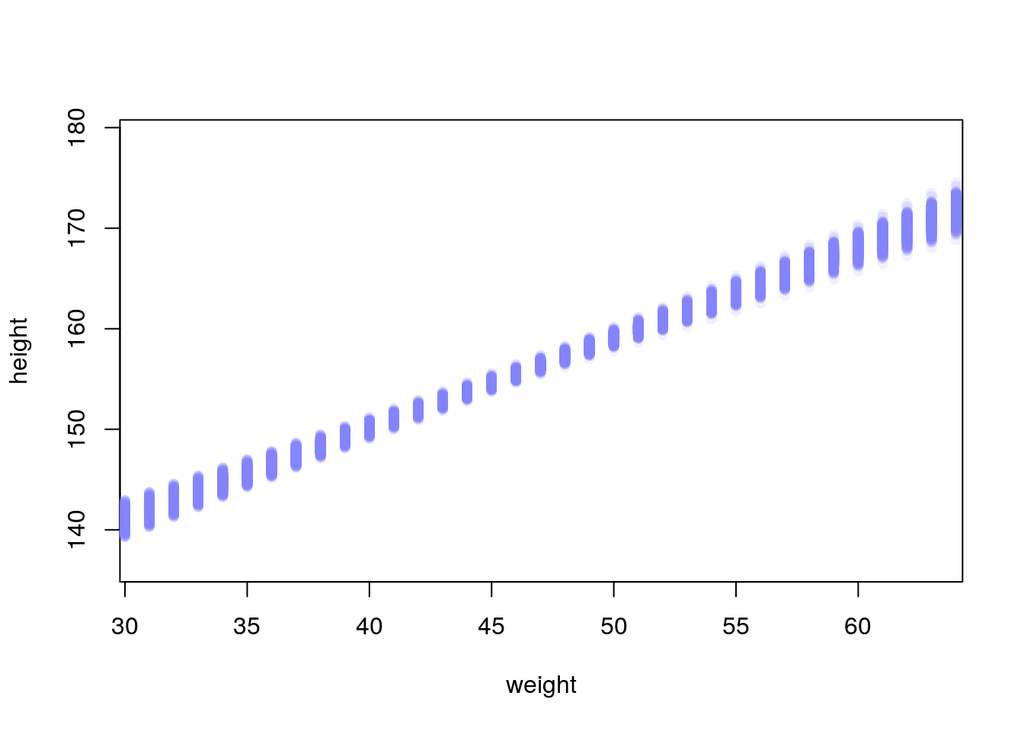

```r
plot(height ~ weight, d2, type = "n")

for (i in 1:nrow(mu)) {
  points(weight.seq, mu[i, ], pch = 16, col = col.alpha(rangi2, 0.1))
}
```

We can get some summary for mu for each weight observation:

```r
mu.mean <- apply(mu, 2, mean)
mu.PI <- apply(mu, 2, PI, prob = 0.89)
```

Plot these summaries:

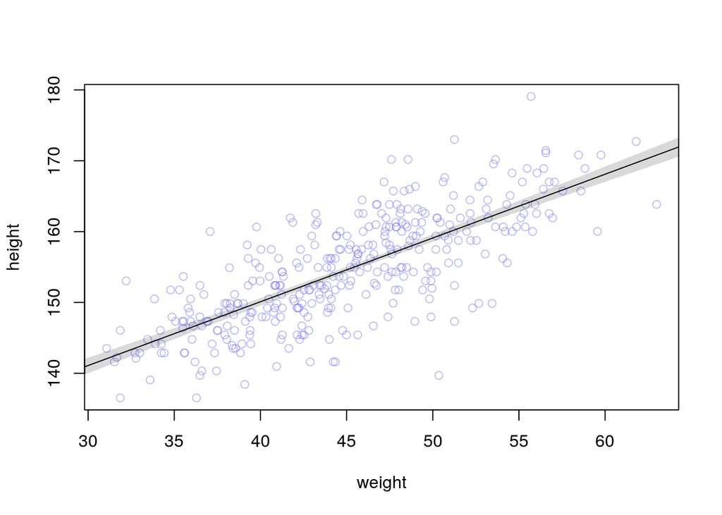

```r
plot(height ~ weight, data = d2, col = col.alpha(rangi2, 0.5))
lines(weight.seq, mu.mean)
shade(mu.PI, weight.seq)
```

## Simulating prediction intervals

The previous section dealt with similating the mean height for a given weight, but we know that actual heights vary around a mean, so we need to bring our $\sigma$ into the frame now. The `sim()` function simulates a variety of heights based on the posterior (not just mean heights):

```r
sim.height <- sim(m4.3, data = list(weight = weight.seq))
height.PI <- apply(sim.height, 2, PI, prob = 0.89)
```

Plot the prediction interval:

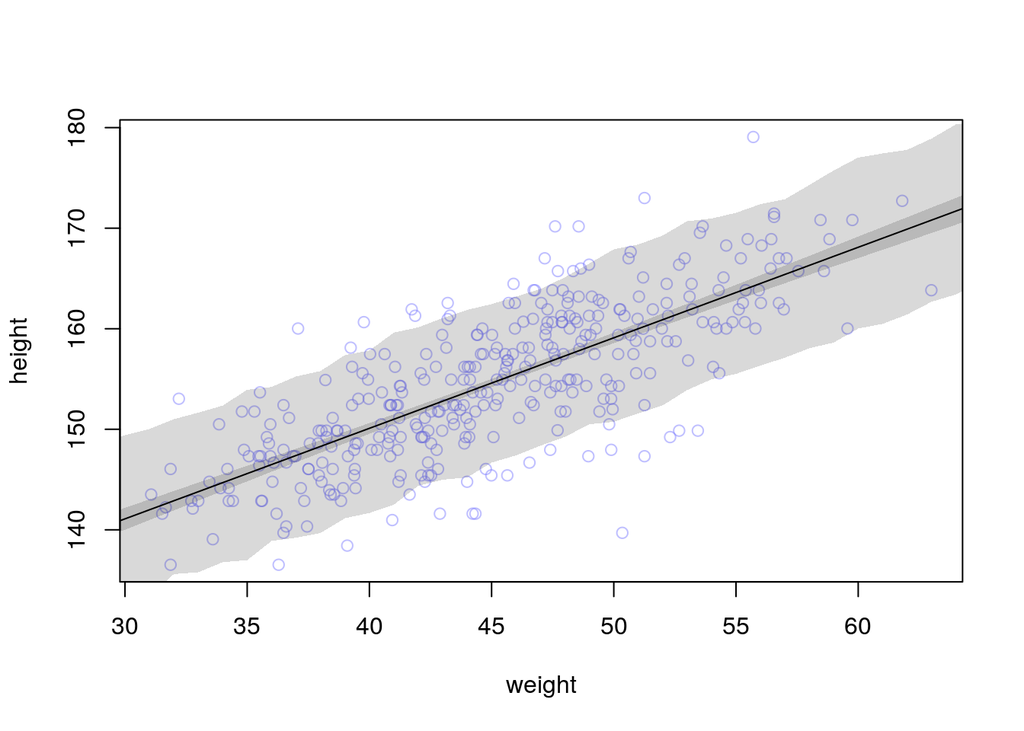

```r
plot(height ~ weight, data = d2, col = col.alpha(rangi2, 0.5))
lines(weight.seq, mu.mean)
shade(mu.PI, weight.seq)
shade(height.PI, weight.seq)
```

## Polynomial regression

Let’s plot the full Howell’s data set:

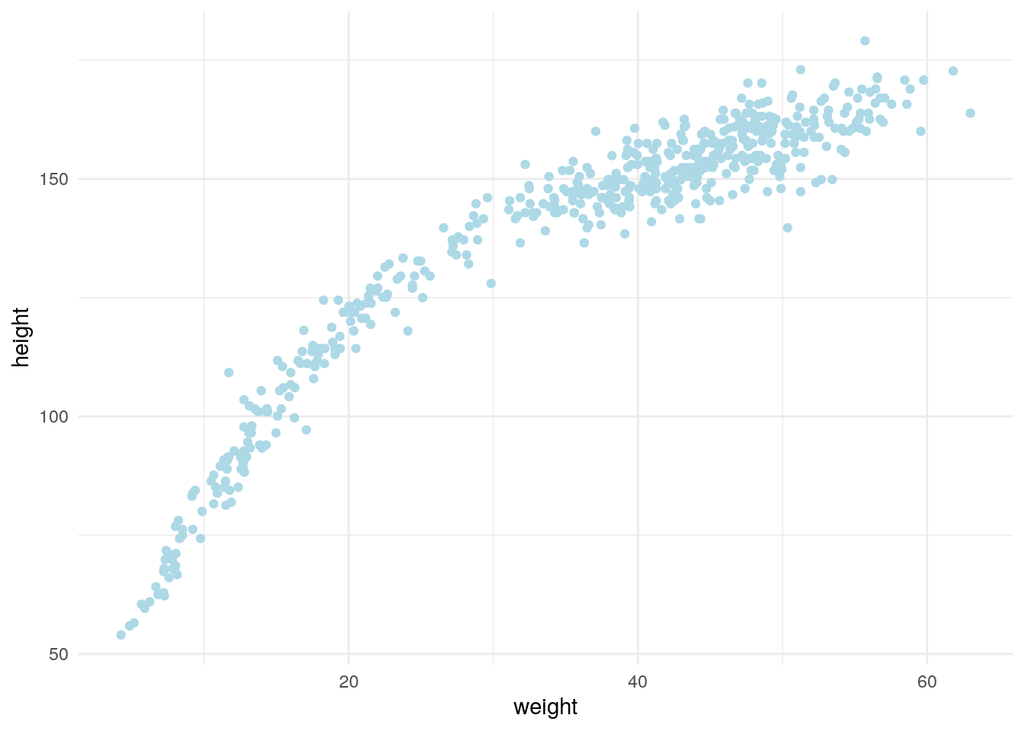

```r
ggplot(data = Howell1, aes(x = weight, y = height)) +
  geom_point(color = "lightblue") +
  theme_minimal()
```

This clearly has some curvature to it. It’s possibly parabolic so it might be well modeled by a quadratic polynomial. Let’s try:

```r
# create standardized diff from mean weight

d$weight_s <-(d$weight - mean(d$weight))/sd(d$weight)
d$weight_s2 <- d$weight_s^2

flist <- alist(
  height ~ dnorm(mu, sigma),
  mu <- a + b1*weight_s + b2*weight_s2,
  a ~ dnorm(178, 20),
  b1 ~ dlnorm(0, 1),
  b2 ~ dnorm(0, 1),
  sigma ~ dunif(0, 50)
)

m4.5 <- quap(flist, data = d)

precis(m4.5)
```

```
##             mean        sd       5.5%      94.5%
## a     146.057307 0.3689781 145.467609 146.647005
## b1     21.733053 0.2888905  21.271351  22.194756
## b2     -7.803203 0.2741857  -8.241404  -7.365001
## sigma   5.774506 0.1764676   5.492477   6.056535
```

Let’s plot this fit:

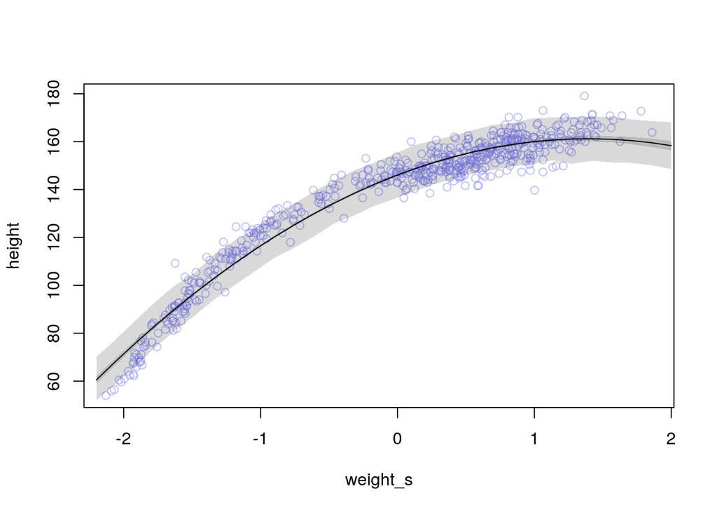

```r
weight.seq <- seq(from = -2.2, to = 2, length.out = 30)
pred_dat <- list(weight_s = weight.seq, weight_s2 = weight.seq^2)
mu <- link(m4.5, data = pred_dat)
mu.mean <- apply(mu, 2, mean)
mu.PI <- apply(mu, 2, PI, prob = 0.89)
sim.height <- sim(m4.5, data = pred_dat)
height.PI <- apply(sim.height, 2, PI, prob = 0.89)

plot(height ~ weight_s, d, col = col.alpha(rangi2, 0.5))
lines(weight.seq, mu.mean)
shade(mu.PI, weight.seq)
shade(height.PI, weight.seq)
```

Nice! Let’s try a cubic:

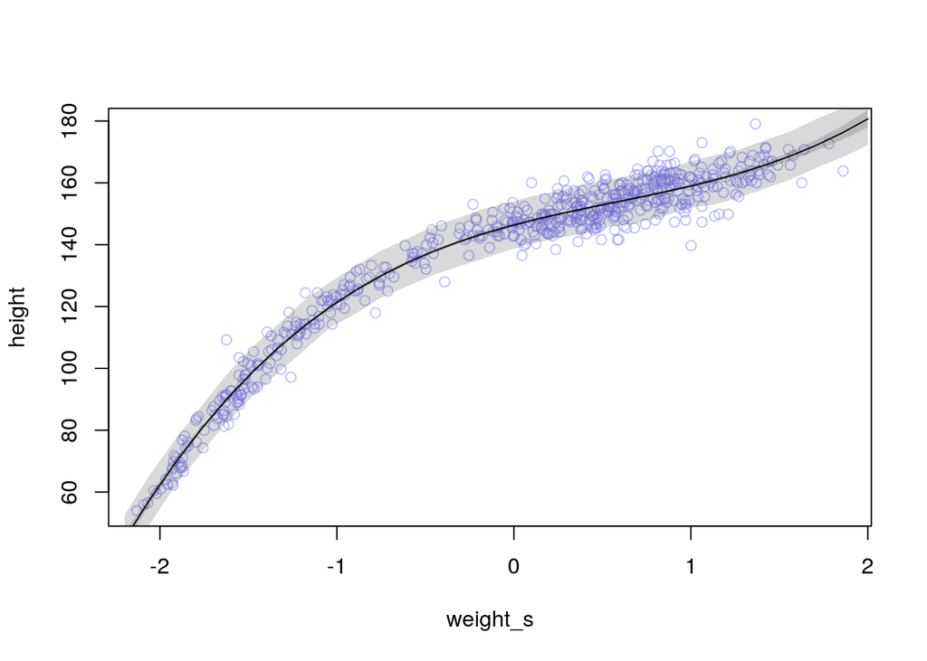

```r
d$weight_s3 <- d$weight_s^3

flist <- alist(
  height ~ dnorm(mu, sigma),
  mu <- a + b1*weight_s + b2*weight_s2 + b3*weight_s3,
  a ~ dnorm(178, 20),
  b1 ~ dlnorm(0, 1),
  b2 ~ dnorm(0, 1),
  b3 ~ dnorm(0, 1),
  sigma ~ dunif(0, 50)
)

m4.6 <- quap(flist, data = d)

pred_dat <- list(weight_s = weight.seq, weight_s2 = weight.seq^2, weight_s3 = weight.seq^3)
mu <- link(m4.6, data = pred_dat)
mu.mean <- apply(mu, 2, mean)
mu.PI <- apply(mu, 2, PI, prob = 0.89)
sim.height <- sim(m4.6, data = pred_dat)
height.PI <- apply(sim.height, 2, PI, prob = 0.89)

plot(height ~ weight_s, d, col = col.alpha(rangi2, 0.5))
lines(weight.seq, mu.mean)
shade(mu.PI, weight.seq)
shade(height.PI, weight.seq)
```

And even a quartic for fun:

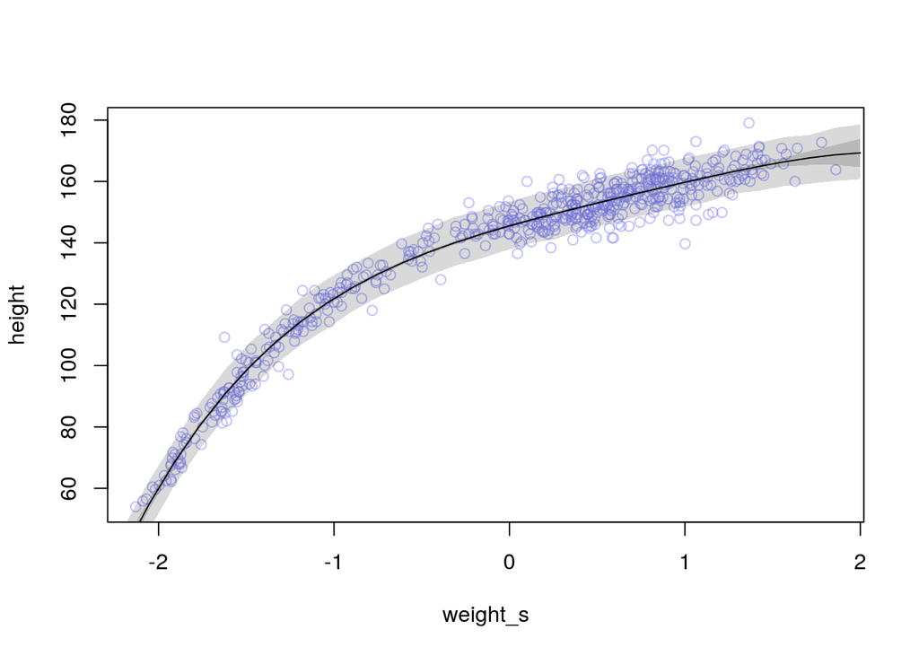

```r
d$weight_s4 <- d$weight_s^4

flist <- alist(
  height ~ dnorm(mu, sigma),
  mu <- a + b1*weight_s + b2*weight_s2 + b3*weight_s3 + b4*weight_s4,
  a ~ dnorm(178, 20),
  b1 ~ dlnorm(0, 1),
  b2 ~ dnorm(0, 1),
  b3 ~ dnorm(0, 1),
  b4 ~ dnorm(0, 1),
  sigma ~ dunif(0, 50)
)

m4.7 <- quap(flist, data = d)

pred_dat <- list(weight_s = weight.seq, weight_s2 = weight.seq^2, weight_s3 = weight.seq^3,
                 weight_s4 = weight.seq^4)
mu <- link(m4.7, data = pred_dat)
mu.mean <- apply(mu, 2, mean)
mu.PI <- apply(mu, 2, PI, prob = 0.89)
sim.height <- sim(m4.7, data = pred_dat)
height.PI <- apply(sim.height, 2, PI, prob = 0.89)

plot(height ~ weight_s, d, col = col.alpha(rangi2, 0.5))
lines(weight.seq, mu.mean)
shade(mu.PI, weight.seq)
shade(height.PI, weight.seq)
```

## Splines

For this we will need the `cherry_blossoms` data set:

```r
data("cherry_blossoms")
d <- cherry_blossoms
precis(d)
```

```
##                   mean          sd      5.5%      94.5%       histogram
## year       1408.000000 350.8845964 867.77000 1948.23000   ▇▇▇▇▇▇▇▇▇▇▇▇▁
## doy         104.540508   6.4070362  94.43000  115.00000        ▁▂▅▇▇▃▁▁
## temp          6.141886   0.6636479   5.15000    7.29470        ▁▃▅▇▃▂▁▁
## temp_upper    7.185151   0.9929206   5.89765    8.90235 ▁▂▅▇▇▅▂▂▁▁▁▁▁▁▁
## temp_lower    5.098941   0.8503496   3.78765    6.37000 ▁▁▁▁▁▁▁▃▅▇▃▂▁▁▁
```

Let’s look at how consistent the first day of blossom has been over the years:

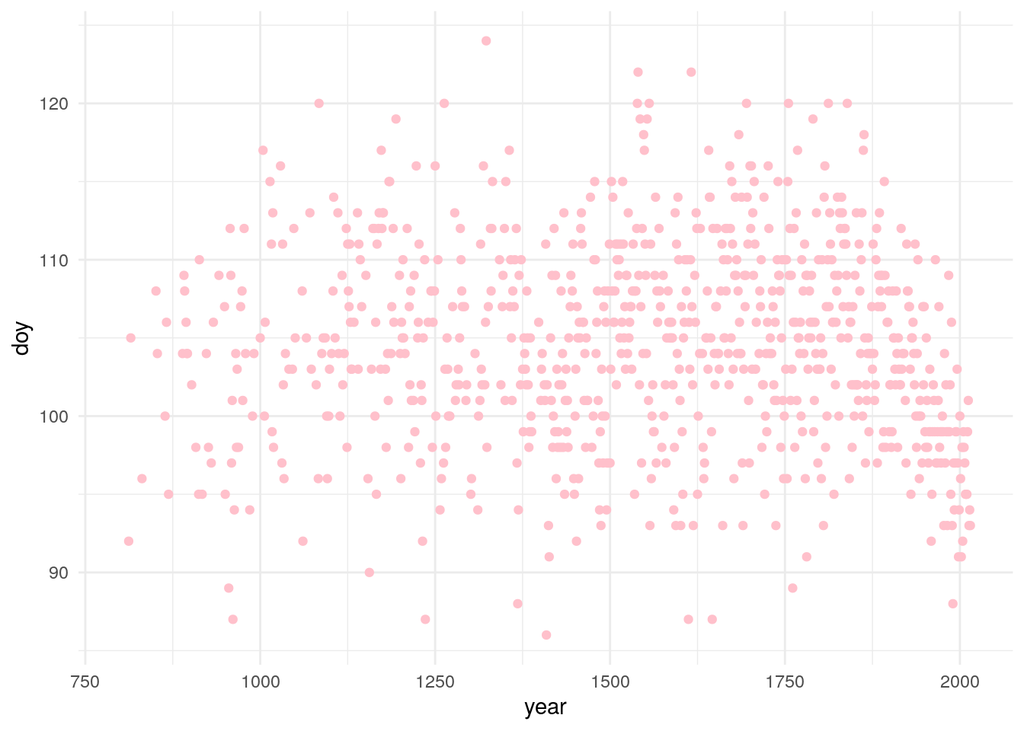

```r
ggplot(data = d) +
  geom_point(aes(x = year, y = doy), color = "pink") +
  theme_minimal()
```

For our B-spine method, we will costruct some knots:

```r
d2 <- d[complete.cases(d$doy), ]
num_knots <- 20
knot_list <- quantile(d2$year, probs = seq(0, 1, length.out = num_knots))
```

Now we will create basis priors for our splines:

```r
library(splines)
B <- bs(d2$year,
        # get rid of the ends
        knots = knot_list[-c(1, num_knots)],
        degree = 3,
        intercept = TRUE)
```

Let’s look at our basis functions:

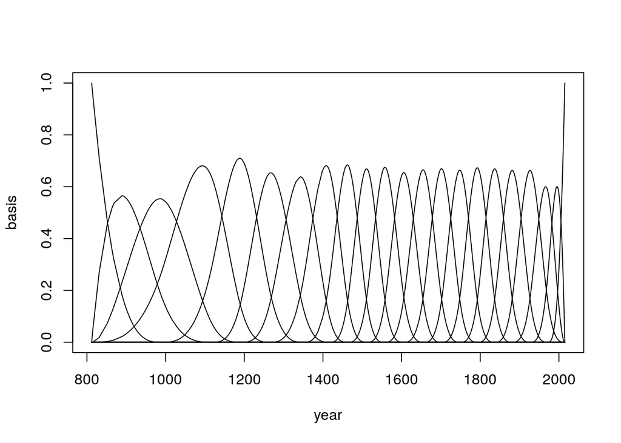

```r
plot(NULL, xlim = range(d2$year), ylim = c(0, 1), xlab = "year", ylab = "basis")
for (i in 1:ncol(B)) {
  lines(d2$year, B[,i])
}
```

OK, let’s build a model with our basis functions:

```r
flist <- alist(
  D ~ dnorm(mu, sigma),
  mu <- a + B %*% w,
  a ~ dnorm(100, 10),
  w ~ dnorm(0, 10),
  sigma ~ dexp(1)
)

m4.8 <- quap(
  flist, data = list(D = d2$doy, B = B), start = list(w = rep(0, ncol(B)))
)

precis(m4.8, depth = 2)
```

```
##              mean        sd        5.5%       94.5%
## w[1]   -3.5185395 3.8919505  -9.7386281   2.7015490
## w[2]   -1.0824747 3.9178376  -7.3439359   5.1789866
## w[3]   -1.2317620 3.5902000  -6.9695950   4.5060711
## w[4]    1.9248187 2.8544557  -2.6371528   6.4867902
## w[5]    4.4383451 2.6683592   0.1737916   8.7028985
## w[6]   -3.1806666 2.8461018  -7.7292869   1.3679537
## w[7]    7.0451440 2.9414343   2.3441638  11.7461242
## w[8]   -4.8499210 2.8196150  -9.3562103  -0.3436316
## w[9]    0.4139548 2.7711878  -4.0149385   4.8428480
## w[10]   2.7565816 2.7636412  -1.6602507   7.1734140
## w[11]   5.4849571 2.8005616   1.0091188   9.9607954
## w[12]  -2.8109294 2.8437328  -7.3557638   1.7339049
## w[13]   4.1804223 2.8379407  -0.3551550   8.7159997
## w[14]   4.2089465 2.8174222  -0.2938384   8.7117313
## w[15]   0.9265454 2.8045580  -3.5556799   5.4087708
## w[16]   1.6037885 2.7910947  -2.8569199   6.0644969
## w[17]   5.1401210 2.8101668   0.6489317   9.6313103
## w[18]   0.4176898 2.8636961  -4.1590497   4.9944293
## w[19]   1.3110212 2.9789045  -3.4498436   6.0718860
## w[20]  -5.1217560 3.3129321 -10.4164613   0.1729493
## w[21]  -6.2114387 3.4568301 -11.7361209  -0.6867565
## w[22]  -8.3392613 3.2572699 -13.5450077  -3.1335150
## a     103.5579987 2.0983859 100.2043728 106.9116247
## sigma   5.8436460 0.1429673   5.6151566   6.0721354
```

Let’s plot the basis posteriors:

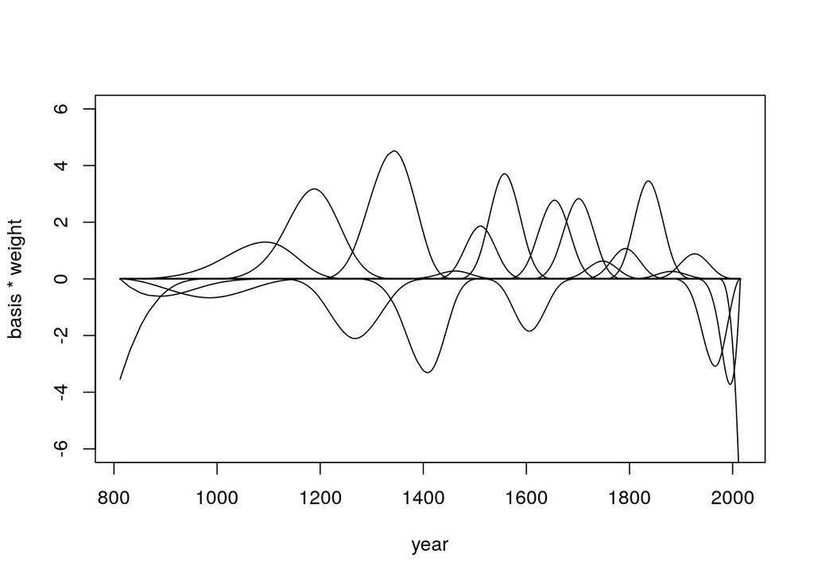

```r
post <- extract.samples(m4.8)
w <- apply(post$w, 2, mean)
plot(NULL, xlim = range(d2$year), ylim = c(-6, 6), xlab = "year", ylab = "basis * weight")
for (i in 1:ncol(B)) {
  lines(d2$year, w[i]*B[ ,i])
}
```

Now we can use these basis posteriors to determine our 97% interval for the mean day of the year:

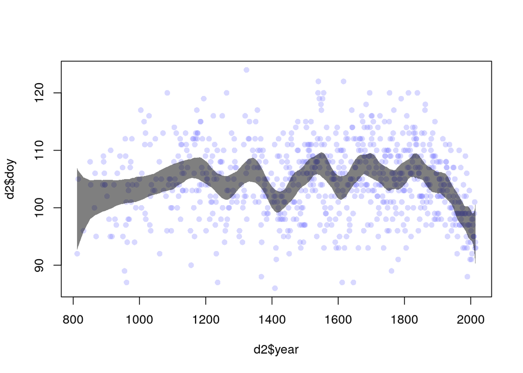

```r
mu <- link(m4.8)
mu_PI <- apply(mu, 2, PI, 0.97)
plot(d2$year, d2$doy, col = col.alpha(rangi2, 0.3), pch = 16)
shade(mu_PI, d2$year, col = col.alpha("black", 0.5))
```

Try in ggplot2:

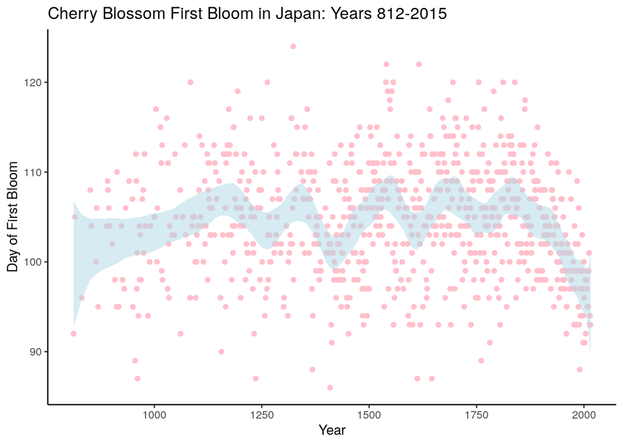

```r
muPI <- as.data.frame(t(mu_PI))
data <- cbind(d2[ ,c("year", "doy")], muPI)

ggplot(data = data, aes(x = year, y = doy)) +
  geom_point(color = "pink") +
  geom_ribbon(aes(ymin = `2%`, ymax = `98%`), fill = "lightblue", alpha = 0.5) +
  theme_classic() +
  labs(x = "Year", y = "Day of First Bloom", title = "Cherry Blossom First Bloom in Japan: Years 812-2015")
```